# Simple Linear Regression Assignment

### Plots with confidence and prediction intervals

Task: Add the 95% confidence and 95% prediction intervals to the scatter plot with the line of best fit, and interpret.

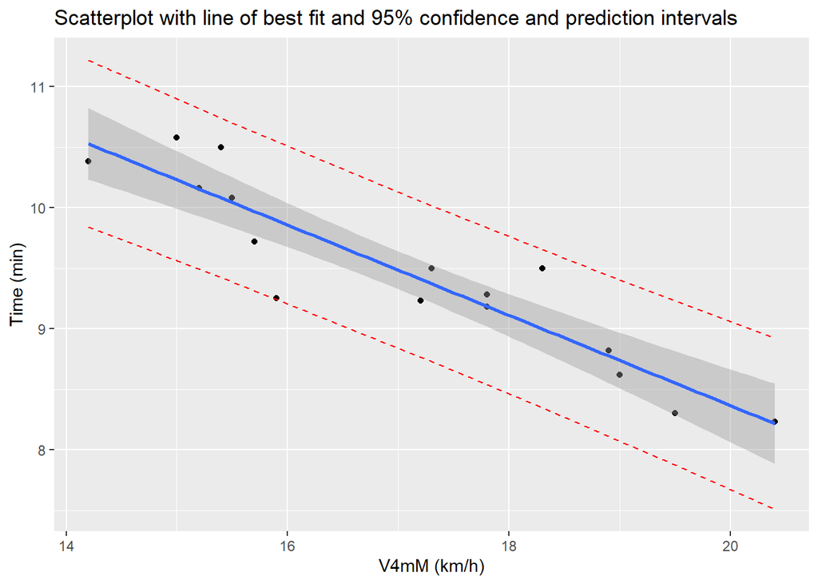

```r
pred.int = predict(Running.model, newdata = running, interval = "prediction")

running2 = cbind(running, pred.int)

ggplot(running2, aes(y = Running.Time, x = v4mM)) +
  geom_point() +
  stat_smooth(method = lm) + # this includes a confidence interval
  geom_line(aes(y = lwr), color = "red", linetype = "dashed") + #  Add prediction intervals
  geom_line(aes(y = upr), color = "red", linetype = "dashed") +
  labs(x = "V4mM (km/h)", y = "Time (min)",
       title = "Scatterplot with line of best fit and 95% confidence and prediction intervals")
```

### More prediction

Task: Predict the running time (i.e. `Running.Time`) when running speed at blood lactate concentration 4 mmol/litre (i.e. `v4mM`) is 18.9 km per hour.

```r
predict(Running.model, newdata = data.frame(v4mM = 18.9))
```

```
##        1
## 8.775336
```

Task: Why is the result here is different from 8.82, the observed running time when running speed at blood lactate concentration 4 mmol/litre (`v4mM`) is 18.9 mmol.l-1? (see observation row 4)

These predictions are based off the prediction interval, meaning that they are likely to contain the response variable for a single new observation of a specific value of the exploratory variable. However, the observed running time would still fall within the 95% confidence interval for that value, so it would not imply that the model is incorrect.

Task: Predict the running time (i.e. `Running.Time`) when `v4mM` is 2.6 km per hour. Explain if you have any concern related to this prediction.

```r
predict(Running.model, newdata = data.frame(v4mM = 2.6))
```

```
##        1
## 14.85286
```

The concern that I would have is that 2.6km/h is not within the range found in the study, and we don’t have any concrete data to base predictions on for that.

### Overall Conclusion

Task: State your overall conclusions from fitting a linear model for the relationship between 3k running time and the running speed at blood lactate concentration 4 mmol/litre.

In conclusion, fitting a linear model to this relationship seems accurate, as there were not any extreme datapoints, there was a very high correlation coefficient, and the majority of datapoints fell within the 95% confidence interval that was predicted.

Therefore it is reasonable to say that a linear regression of this relationship can be used to accurately predict the time taken to run 3km given the velocity attained at a blood lactate concentration of 4mmol/litre.